# Visuals for Map Data

Muhammad Hilmi Abdul Majid

## Introduction

We will continue with exploring various visuals and graphs we can use to display data, depending on the type of data we have and what we want to show from the data. In this topic, focus will be given to map or geospatial data, in which the data contains a variable that represents location. In this case, we may want to plot the locations on a map, or perhaps we want to compare values between locations on a map.

As usual, we first load the `ggplot2` and `dplyr` packages as we will be using them.

```r
library(ggplot2)
library(dplyr)
```

We will be using two data examples here. First, is the location of universities in Peninsular Malaysia. The data contains the shortform name and the address of the public universities in Malaysia not including in Sabah and Sarawak.

```r
Name <- c('UM','USM','UKM','UPM','UTM','UIAM','UUM','UPSI','USIM',
          'UiTM','UMT','UTHM','UTeM','UPMSA','UniMAP','UniSZA','UMK','UPNM')

Address <-
  c('Universiti Malaya, Lembah Pantai,50603 Kuala Lumpur',
    'Universiti Sains Malaysia, 11800 USM Penang, Pulau Pinang',
    'Universiti Kebangsaan Malaysia, 43600 Bangi,Selangor',
    'Universiti Putra Malaysia, 43400 Serdang,Selangor',
    'Universiti Teknologi Malaysia), 81310 Skudai, Johor ',
    'Universiti Islam Antarabangsa Malaysia, Jalan Gombak, 53100 Gombak, Selangor',
    'Universiti Utara Malaysia, 06010 UUM Sintok, Kedah ',
    'Universiti Pendidikan Sultan Idris, Jalan Slim, 35900 Tanjung Malim, Perak',
    'Universiti Sains Islam Malaysia, Bandar Baru Nilai, 71800 Nilai, Negeri Sembilan',
    'Universiti Teknologi MARA, 40450 Shah Alam, Selangor ',
    'Universiti Malaysia Terengganu, 21030,Kuala Terengganu, Terengganu',
    'Universiti Tun Hussein Onn Malaysia, 86400 Parit Raja, Batu Pahat, Johor',
    'Universiti Teknikal Malaysia Melaka, Hang Tuah Jaya, 76100 Durian Tunggal, Melaka',
    'Universiti Malaysia Pahang Al-Sultan Abdullah, 26600 Pekan, Pahang',
    'Universiti Malaysia Perlis, Kampus Alam UniMAP Pauh Putra, 02600 Arau, Perlis',
    'Universiti Sultan Zainal Abidin, Gong Badak, 21300 Kuala Nerus, Terengganu',
    'Universiti Malaysia Kelantan, 16300 Bachok, Kelantan',
    'Universiti Pertahanan Nasional Malaysia, Kem Sungai Besi, 57000 Kuala Lumpur')

university <- data.frame(Name, Address)
```

The second example used in this topic is the COVID-19 data by the Malaysian Ministry of Health. It contains the cases and proportion of vaccination for the first dose of vaccine by different states in Malaysia.

```r
State <- c('Johor','Kedah','Kelantan','Melaka','Negeri Sembilan','Pahang',
           'Perak','Perlis','Pulau Pinang','Sabah','Sarawak','Selangor',
           'Terengganu','Kuala Lumpur','Labuan','Putrajaya')

Covid_cases <- c(418725,332790,269078,164139,244317,191193,251336,21290,
                 324179,414510,334544,1636708,143307,525004,24020,39196)

Prop_vaccinated <- c(0.885, 0.774, 0.650, 0.849, 0.916, 0.760, 0.807, 0.850,
                     0.922, 0.683, 0.889, 1.032, 0.735, 1.032, 0.896, 1.032)

covid <- data.frame(State, Covid_cases, Prop_vaccinated)
```

## Geocoding

Before we go through the visuals and graphs, it is important first to understand how map data works. Map data typically contains the longitude and latitude that represent position in the globe. This can be difficult sometimes unless we manually search the coordinates on the map.

Alternatively, we can use `tidygeocoder` package and the `geocode()` function within it to search the longitude and latitude of an address using several methods such as OpenStreetMap, ArcGis, Google, and Bing. Note however that only the first two methods are easily available to be used whereas other methods require user to provide the API key for accessing their services. You can read more on this by looking at the help page for `geo()` by running `?geo` or `help(geo)`.

In the code below, the ArcGis method is used for finding coordinates for university instead of OpenStreetMap. This is because the OpenStreetMap fails to find some universities. But the COVID-19 data works fine with either of them.

```r
# install(tidygeocoder)  # In case you have not downloaded it yet
library(tidygeocoder)

# Add the longitude and latitude according to address, using ArcGis
university2 <- geocode(university, address=Address, method="arcgis")
head(university2)
```

```
## # A tibble: 6 × 4
##   Name  Address                                                        lat  long
##   <chr> <chr>                                                        <dbl> <dbl>
## 1 UM    "Universiti Malaya, Lembah Pantai,50603 Kuala Lumpur"         3.11  102.
## 2 USM   "Universiti Sains Malaysia, 11800 USM Penang, Pulau Pinang"   5.35  100.
## 3 UKM   "Universiti Kebangsaan Malaysia, 43600 Bangi,Selangor"        2.92  102.
## 4 UPM   "Universiti Putra Malaysia, 43400 Serdang,Selangor"           3.00  102.
## 5 UTM   "Universiti Teknologi Malaysia), 81310 Skudai, Johor "        1.56  104.
## 6 UIAM  "Universiti Islam Antarabangsa Malaysia, Jalan Gombak, 5310…  3.25  102.
```

```r
# Add the longitude and latitude according to state, using ArcGis
covid2 <- geocode(covid, state=State)
head(covid2)
```

```
## # A tibble: 6 × 5
##   State           Covid_cases Prop_vaccinated   lat  long
##   <chr>                 <dbl>           <dbl> <dbl> <dbl>
## 1 Johor                418725           0.885  2.02  103.
## 2 Kedah                332790           0.774  5.81  101.
## 3 Kelantan             269078           0.65   5.40  102.
## 4 Melaka               164139           0.849  2.33  102.
## 5 Negeri Sembilan      244317           0.916  2.78  102.
## 6 Pahang               191193           0.76   3.62  103.
```

We can see that new columns are created which shows the longitude and latitude positions of the university addresses and the states in Malaysia. We cab then use these positions to draw them on a map.

## Drawing Map Borders

Another important element of drawing map data, is to draw the map borders. We can use the `maps` or the `rworldmap` packages to draw world maps and country-level maps. However, for state-level maps, we may require to download shapefiles from other sources.

Let’s use the `maps` package first and see how we draw map borders. To do draw the borders, we first save the international countries map data using `map_data("world")`. Then, we can use `geom_polygon()` to draw the borders using `x=long`, `y=lat`, and `group=group` which forms polygons based on the x and y coordinates, for each group.

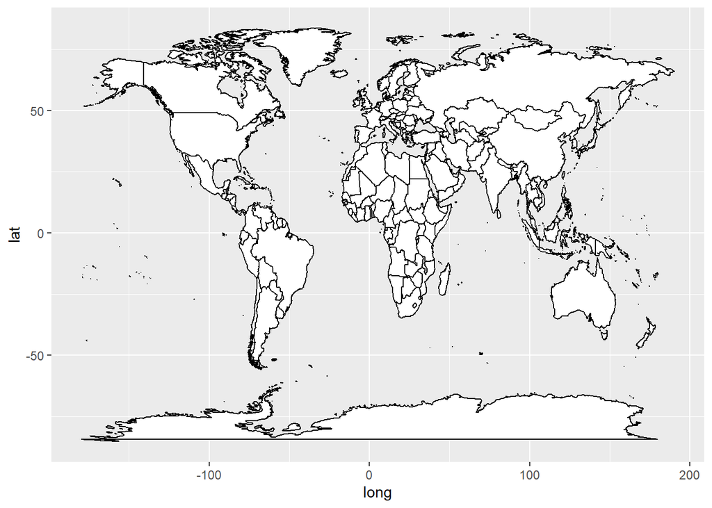

```r
library(maps)

# Use world map data
global <- map_data("world")

# Specify the data and mapping
ggplot(data=global, mapping=aes(x=long, y=lat, group=group)) +

  # Draw polygons based on the mapping to form map boundary
  geom_polygon(fill="white", color="black")
```

If we want to go to specific countries or regions, we can filter the map data based on the `region` or `subregion` column.

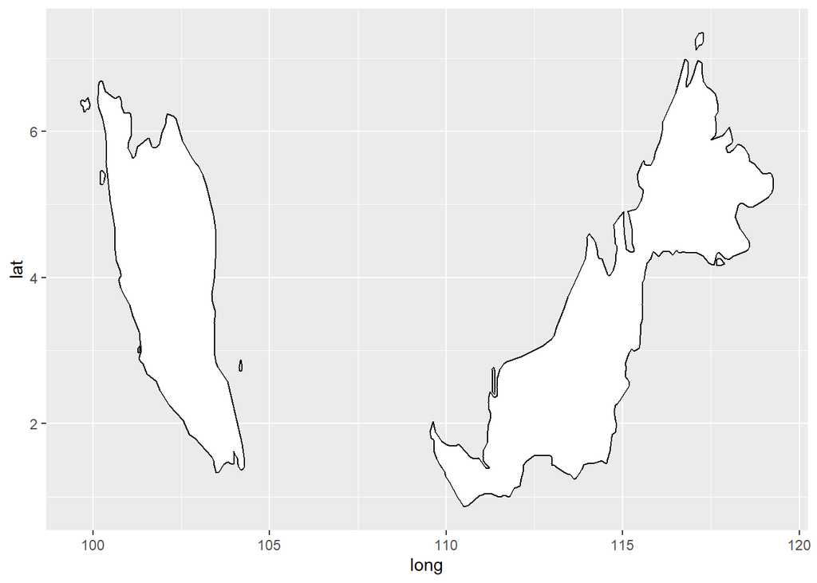

```r
# Filter world map data for Malaysia only
msia <- filter(global, region=="Malaysia")

# Specify the data and mapping
ggplot(data=msia, mapping=aes(x=long, y=lat, group=group)) +

  # Draw polygons based on the mapping to form map boundary
  geom_polygon(fill="white", color="black")
```

Note that the produced plot may appear stretched. To maintain the longitude-latitude scale ratio, we can add either `coord_sf()`, or `coord_fixed()` (with the default `ratio=1`) to the chain.

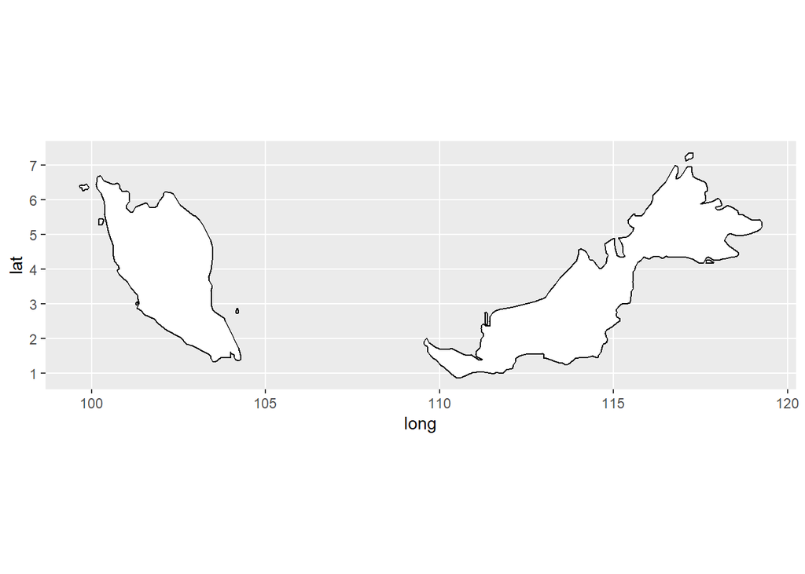

```r
# Specify the data and mapping
ggplot(data=msia, mapping=aes(x=long, y=lat, group=group)) +

  # Draw polygons based on the mapping to form map boundary
  geom_polygon(fill="white", color="black") +

  # Maintain x-y scale ratio
  coord_sf()
```

## Shapefiles

As mentioned, the map region and border data in `maps` and `rworldmap` only contains country-level border, and not state or lower-level borders. If we want to draw state or lower-level map boundaries, we may have to download the shapefiles on the internet, and load it into R.

So what is a shapefile? A shapefile is a standardized geospatial vector data used in Geographic Information System (GIS) software that contains geometric location of an area. It contains at least three files:

1. *.shp*: The shape format. Contains geometry features of the area.
2. *.shx*: The shape index format. Contains shape index of the geometry.
3. *.dbf*: The attribute format. Contains attributes or metadata for the shapes.

The details about what shapefiles are do not matter much. Just know that they are commonly used when drawing maps.

There are various websites you can use to download administrative level boundaries such as https://www.naturalearthdata.com/ or https://www.igismap.com/. But for this example, we will be using shapefiles from https://simplemaps.com/gis/country/my which contains state-level boundaries in Malaysia. Go to the website and download the shapefile. Then, unzip the downloaded file into a folder.

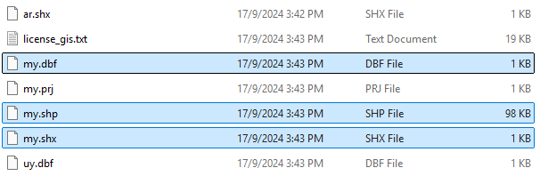

Unzip the download file to see the three files.

To read the shapefile, we will use the `st_read()` function from the `sf` package. The `sf` package (short for ‘simple features’) is designed for handling map and geospatial data. After reading the file (you can choose either the *.shp*, *.shx*, or *.dbf*), we can use `geom_sf()` function to draw the map boundaries after setting the `geometry` in the `aes()` mapping.

```r
# install.packages("sf")
library(sf)

# Read the shape file
# You can use .shp, .shx, or .dbf but all files must be in same folder
MY_map_sf <- st_read("misc/malaysia shapefile/my.shp")
```

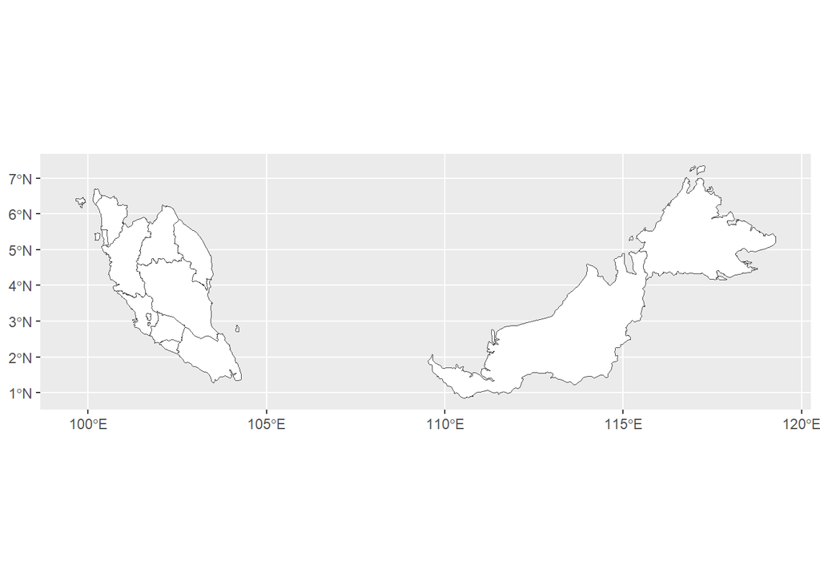

```r
# Specify the data and mapping. Note the geometry argument for aes()
ggplot(data=MY_map_sf, mapping=aes(geometry=geometry)) +

  # Draw geometry based on shapefile
  geom_sf(color="grey25", fill="white")
```

Another way of downloading shapefiles for countries is by using the `rnaturalearth`, `rnaturalearthdata`, and `rnaturalearthhires` packages. The former two can be downloaded from CRAN, but `rnaturalearthhires` is currently not in CRAN because of its file size. But it can be downloaded from the github page https://github.com/ropensci/rnaturalearthhires. For state-level boundaries, the `rnaturalearthhires` package is required.

Below is the code used to download the required packages and to draw the map.

```r
# Install packages from CRAN
install.packages(c("rnaturalearth", "rnaturalearthdata", "remotes"))

# Install package directly from github
remotes::install_github("ropensci/rnaturalearthhires")
install.packages("rnaturalearthhires",
                 repos = "https://ropensci.r-universe.dev", type = "source")
```

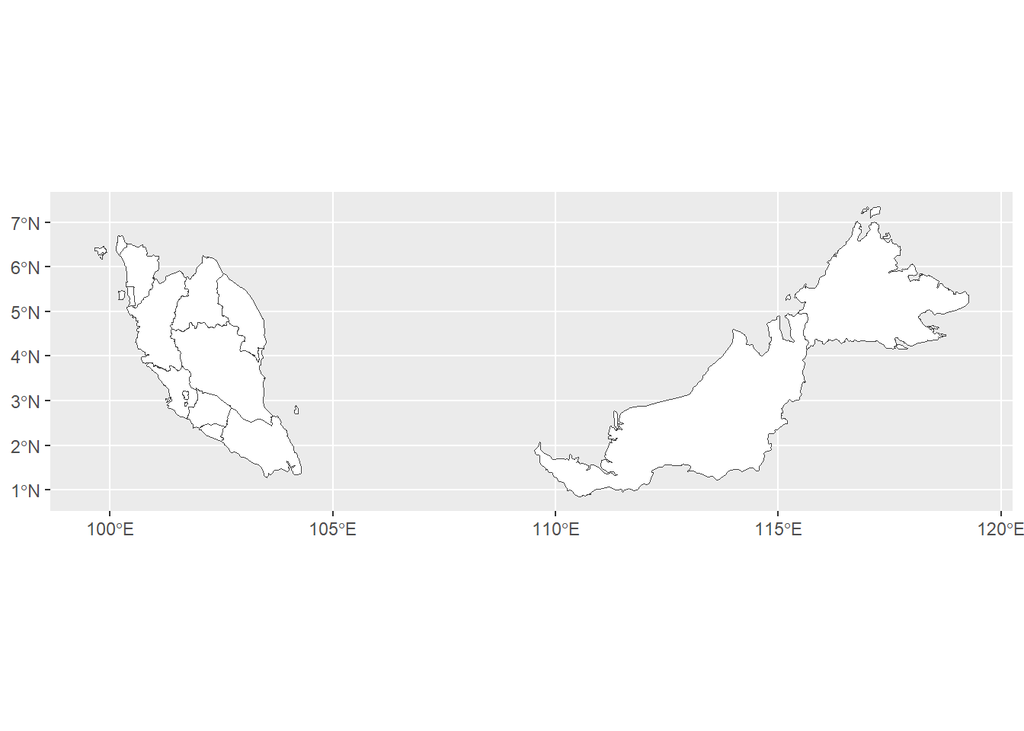

```r
library(rnaturalearth)
library(rnaturalearthdata)
library(rnaturalearthhires)

# Use natural earth state-level data for Malaysia
MY_map_sf2 <- ne_states(country="Malaysia")

# Specify the data and mapping
ggplot(data=MY_map_sf2, mapping=aes(geometry=geometry)) +

  # Draw geometry based on shapefile
  geom_sf(color="grey25", fill="white")
```

## Dot Density Maps

We can finally proceed with drawing visuals and graphs for map or geospatial data. The first visual that will be introduced here is the dot density map, which simply draws the map boundaries and dots/points on the map to show locations.

We do this by using `geom_polygon()` or `geom_sf()` (if you use shapefiles), and then plotting the dots/points using `geom_point()` with the `x=long` and `y=lat` mapping. Note that the `geom_polygon()` or `geom_sf()` use different data than `geom_point()`. Thus the data has to be specified differently when calling the functions.

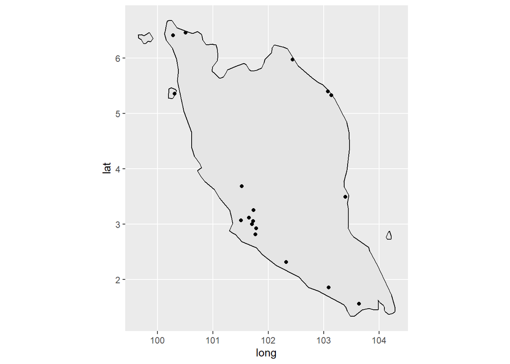

```r
# Filter map data for Peninsular Malaysia only
MY_Peninsular_map <- map_data("world") %>%
  filter(region=="Malaysia" & subregion %in% c("Langkawi", "Pinang", "Tioman",
                                               "Malay Penninsula"))

# Start ggplot chain
ggplot() +

  # Draw polygon using the given data and mapping
  geom_polygon(data=MY_Peninsular_map, mapping=aes(x=long, y=lat, group=group),
               fill="grey90", color="black") +

  # Draw points using the given data and mapping
  geom_point(data=university2, mapping=aes(x=long, y=lat)) +

  # Maintain x-y scale ratio
  coord_sf()
```

To further improve the plot above, we can add labels to show which location is for which university. We can use `geom_label()` to do that, but this results in overlapping labels. Alternatively, we can use `geom_label_repel()` from the `ggrepel` package to make non-overlapping labels.

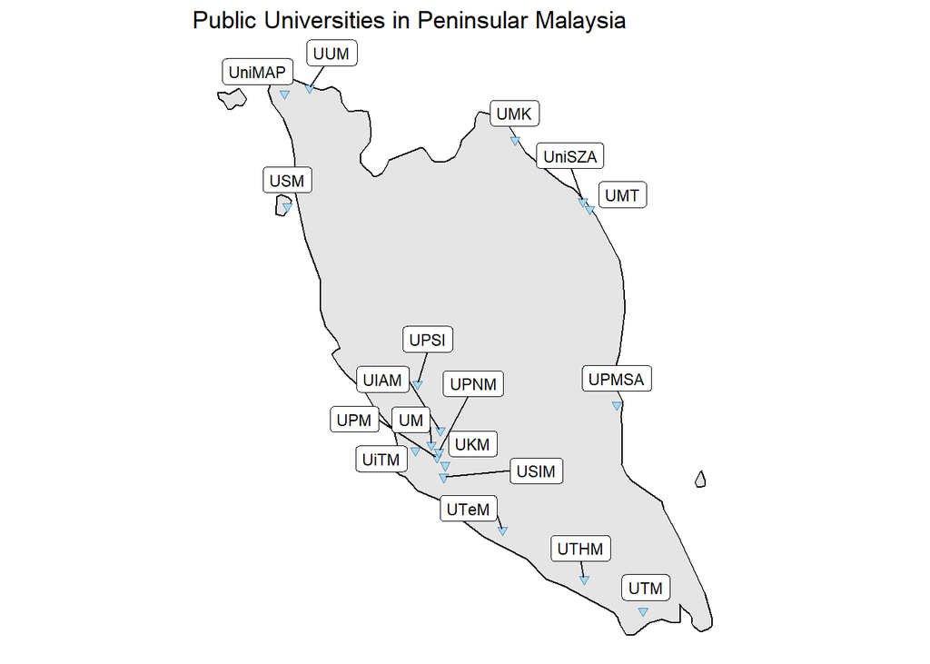

```r
# install.packages("ggrepel)
library(ggrepel)

# Start ggplot chain
ggplot() +

  # Draw polygon using the given data and mapping
  geom_polygon(data=MY_Peninsular_map, mapping=aes(x=long, y=lat, group=group),
               fill="grey90", color="black") +

  # Draw points using the given data and mapping
  geom_point(data=university2, mapping=aes(x=long, y=lat),
             color="steelblue", fill="lightblue", shape=25) +

  # Add labels using Name that do not overlap or repel each other
  # Move label 0.25 above the point, increase size and repulstion force
  geom_label_repel(data=university2, mapping=aes(x=long, y=lat, label=Name),
                   nudge_y = 0.25,
                   size=3,
                   force=10) +

  # Maintain x-y scale ratio
  coord_sf() +

  # Add title
  labs(title="Public Universities in Peninsular Malaysia") +

  # Use void theme to remove background and grids
  theme_void()
```

We can also make a bubble chart on the map by varying the size of dots according to some measurement. We do this by assigning the `size` argument in the `aes()` mapping for `geom_point()`. In the plot below, we can see that Selangor has the highest number of COVID-19 cases, followed by Kuala Lumpur.

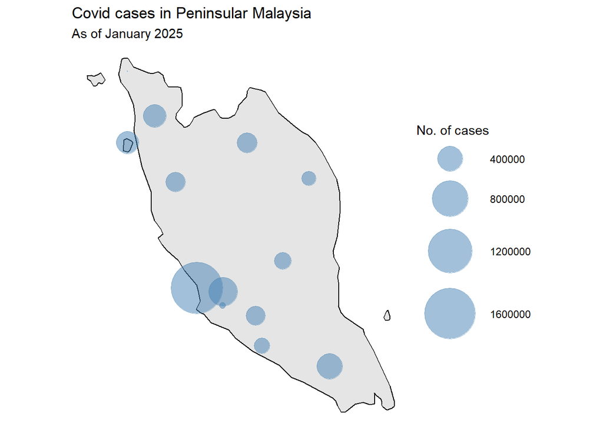

```r
# Filter covid data for Peninsular Malaysia only
covid_peninsular <- filter(covid2, State != c("Sabah","Sarawak","Labuan"))

# Start ggplot chain
ggplot() +

  # Draw polygon using the given data and mapping
  geom_polygon(data=MY_Peninsular_map, mapping=aes(x=long, y=lat, group=group),
               fill="grey90", color="black") +

  # Draw points using the given data and mapping. Note the size argument for aes()
  geom_point(data=covid_peninsular, mapping=aes(x=long, y=lat, size=Covid_cases),
             alpha=0.5,
             color="steelblue") +

  # Increase the size of the bubbles by changing the range
  scale_size(range = c(0, 20)) +

  # Maintain x-y scale ratio
  coord_sf() +

  # Use void theme to remove background and grids
  theme_void() +

  # Add title, subtitle. Change legend title
  labs(title="Covid cases in Peninsular Malaysia",
       subtitle="As of January 2025",
       size="No. of cases")
```

## Choropleth Maps

The next visual that will be used in this topic is the choropleth map. The choropleth map is simply a heatmap drawn on top of a map. Using this visual, we can compare values between regions by the color.

To draw a choropleth map, we first have to join together the map boundary data, and the value of interest. . But before that, we may need to check whether there is any difference in names between columns in two different data frames. For example, if one data frame uses “johor” and another uses “Johor”, there will be problem later when joining the two data frames. To check for any differences, we can use the `symdiff()` function from the `dplyr` package.

```r
# Check if there is any difference between the names inside the two columns
symdiff(MY_map_sf$name, covid$State)
```

```
## character(0)
```

The output shows there is no differences in naming between the two, and all characters in one column appear in the other column.

To join the two data frames, we can use the `left_join()` function in `dplyr` package. This function joins two data frames by a similar variable that we can set using the `by` argument.

```r
# Join the two data frames by state
joined_map <- MY_map_sf %>% left_join(covid, by=join_by(name == State))
head(joined_map)
```

```
## Simple feature collection with 6 features and 5 fields
## Geometry type: MULTIPOLYGON
## Dimension:     XY
## Bounding box:  xmin: 99.64523 ymin: 0.8513703 xmax: 119.2781 ymax: 7.35578
## Geodetic CRS:  WGS 84
##     id     name                 source Covid_cases Prop_vaccinated
## 1 MY12    Sabah https://simplemaps.com      414510           0.683
## 2 MY09   Perlis https://simplemaps.com       21290           0.850
## 3 MY02    Kedah https://simplemaps.com      332790           0.774
## 4 MY03 Kelantan https://simplemaps.com      269078           0.650
## 5 MY08    Perak https://simplemaps.com      251336           0.807
## 6 MY13  Sarawak https://simplemaps.com      334544           0.889
##                         geometry
## 1 MULTIPOLYGON (((117.907 4.1...
## 2 MULTIPOLYGON (((100.3777 6....
## 3 MULTIPOLYGON (((100.1987 6....
## 4 MULTIPOLYGON (((102.542 5.8...
## 5 MULTIPOLYGON (((100.5037 5....
## 6 MULTIPOLYGON (((115.4216 4....
```

We see now that the joined data frame contains all columns from both tables.

Finally, we can draw the choropleth map by using `geom_sf()` (if we are using shapefiles) and specifying the `fill` argument in its `aes()` mapping.

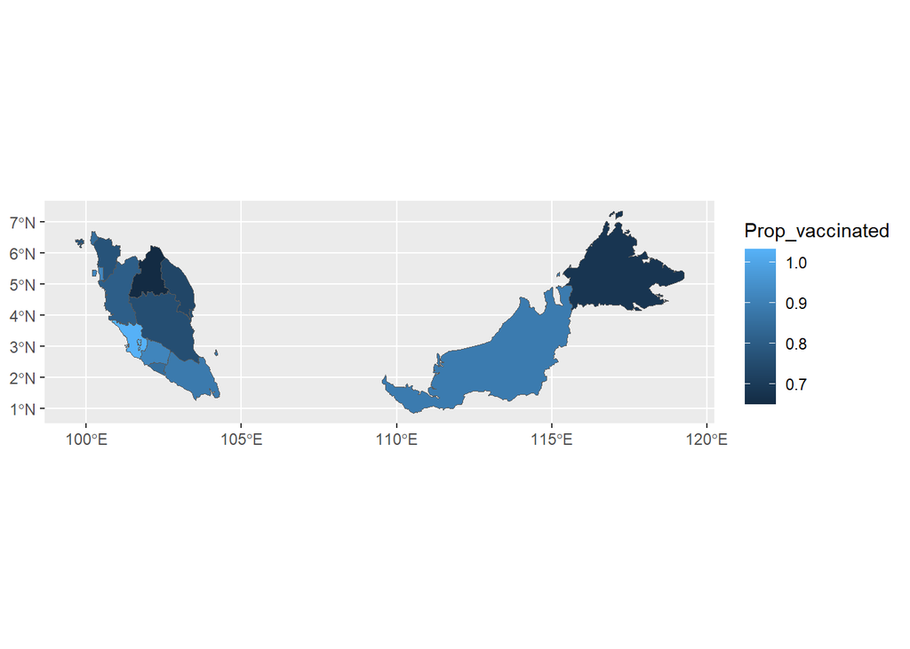

```r
# Specify the data and mapping. Note the fill argument for aes()
ggplot(data=joined_map, mapping=aes(geometry=geometry, fill=Prop_vaccinated)) +

  # Draw the shapefile according to the global mapping
  geom_sf()
```

We see that Selangor, Kuala Lumpur and Putrajaya have the highest proportions of vaccinated residents. On the other hand, Kelantan and Sabah have the lowest proportions.

We can improve the above plot by changing a few visual properties.

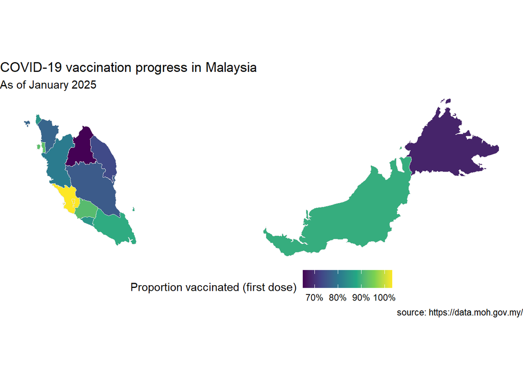

```r
# Specify the data and mapping
ggplot(data=joined_map, mapping=aes(geometry=geometry, fill=Prop_vaccinated)) +

  # Draw the shapefile according to the global mapping
  geom_sf(color="grey90") +

  # Use viridis color and percentage for fill scales
  scale_fill_viridis_c(labels = scales::label_percent()) +

  # Use void theme to remove background and grids
  theme_void() +

  # Change the legend position
  theme(legend.position = "bottom") +

  # Ad title, subtitle, caption. Change legend title
  labs(title="COVID-19 vaccination progress in Malaysia",
       subtitle="As of January 2025",
       caption="source: https://data.moh.gov.my/",
       fill="Proportion vaccinated (first dose)")
```

## Drawing Map with `mapview`

If you want to make interactive maps, one option is to use the `mapview` package in combination with the `sf` package. If you read this note using the PDF format, the map will appear static and not interactive, as it will appear as a screenshot of the html output. But, you should be able to interact with the map if you read this note in html format with a web browser.

In the code below, we use the filtered data from `university2` data frame with the longitude and latitude coordinates of universities. We use `st_as_sf()` function from the `sf` package to convert the data frame into a ‘simple feature’ object and use `crs=4326` which is the popular coordinate reference system. The `mapview()` function then generates the interactive graph using OpenStreetMap and places the coordinates according to the longitude and latitude coordinates of the universities.

```r
# install.packages("mapview")
library(mapview)

# Filter the data for selected universities
university3 <- filter(university2, Name %in% c("UKM","UPM","UiTM","UPNM",
                                               "UIAM","UM","USIM"))

# Convert the data frame to simple feature with geometry
mymap <- st_as_sf(university3, coords=c("long","lat"), crs=4326)

# Draw the map using OpenStreeMap
mapview(mymap)
```

[interactive chart not shown]

Note that you can use the `ggmap` package if you want to create a static map using Google Map or Staten Map Tiles. However, they require users to register for the services to obtain API keys. In some cases, you may even have to pay for using them.

## Conclusion

In this topic, we have explored some ways to draw map data, but we mainly focus on dot density maps and choropleth maps. To draw these visuals, there are some steps that we have to take into account including specifying the longitude and latitude coordinates, drawing map borders and boundaries, as well as using shapefiles. This topic will be the last topic for us to explore various visuals and graphs. In the next topic, we will discuss more on customizing graphs.